# Credit Metrics

Jakub Augustynek

29 04 2019

## Ratingi kredytowe

**Rating kredytowy** jest to kredytowa ocena klasyfikacyjna oceniająca i kategoryzująca poziom zdolności kredytowej danego podmiotu, długu lub zobowiązania finansowego lub emitenta takich długów lub zobowiązań finansowych.  
Agencje ratingowe w celu oceny wiarygodności kredytowej używają kilku standardowych systemów. Na podstawie różnych czynników oceniają jakość obligacji używając do tego ratingów.

Początki ratingów sięgają XIX wieku, związane są z kryzysem finansowym w Stanach Zjednoczonych. Niektóre agencje handlowe zaczęły wydawać świadectwa oceniające zdolność kupców i hurtowników to regulowania zobowiązań finansowych.

#### Agencje ratingowe

Agencje ratingowe oceniają nie tylko przedsiębiorstwa i fundusze inwestycyjne, ale także państwa i samorządy lokalne.  
Jednymi z najważniejszych agencji ratingowych sa:

- Standard & Poor’s (S&P)
- Fitch
- Moody’s

#### Ratingi

W agencjach S&P i Fitch możliwe ratingi od najwyższego do najniższego to:

- AAA
- AA
- A
- BBB Obligacje od BBB wzwyż mają **standard inwestycyjny**
- BB
- B
- CCC
- D **Bankructwo**

#### Kraje

W projekcie tym portfel będzie się składał z obligacji 3 letnich następujących krajów:

- **Kanada** - rating **AAA**
- **Wielka Brytania** - rating **AA**
- **Filipiny** - rating **BBB**
- **Turcja** - rating **B**

Kraje te są dość zróżnicowane pod względem ratingu, Kanada ma najwyższy z możliwych, a Turcja jest poniżej standardu inwestycyjnego.  
Są dużymi krajami, Kanada jest drugim największym krajem, Turcja ma ponad dwa razy większą powierzchnię od Polski, a Filipiny i Wielka Brytania są podobnej wielkości.

### Kanada

Kanada ma **wysoką wiarygodność kredytową**, po prześledzeniu danych historycznych zauważyłem, że rating waha się między AAA, a AA.  
PKB per capita wynosi ponad 51 315 USD. Jest to najwyższa wartość z wybranych przeze mnie do portfela państw. Roczne tempo wzrostu PKB to około 1,6 %.

### Wielka Brytania

Wielka Brytania przez wiele lat miała rating AAA, od 2016 roku jej **wiarygodność kredytowa spadła** do AA. Właśnie w 2016 roku było głosowanie w sprawie BREXITU, czyli wyjścia Wielkiej Brytanii z Unii Europejskiej, wydaje mi się, że mogło to mieć wpływ na zmniejszenie ratingu. Według portalu *tradingeconomics.com* **perspektywa zmian ratingu jest negatywna**. PKB per capita wynosi 42 519 USD, jest wysokie, w rankingu największego PKB per capita znajduje się kilka miejsc za Kanadą. Roczne tempo wzrostu PKB to 1,4 %. Ma tendecję wzrostową.

### Filipiny

Filipiny mają rating BBB, czyli są **na granicy standardu inwestycyjnego**. W ciągu ostatnich lat kraj ten **sukcesywnie zwiększał swoją wiarygodność kredytową**. Od roku 2013 ma rating BBB, wcześniej rating miał wartość BB, lub B. Według portalu *tradingeconomics.com* **perspektywa zmian ratingu jest pozytywna**. PKB per capita wynosi 2891 USD, nie jest to wartość duża w porównaniu do poprzednio wymienionych państw, ale tempo wztostu PKB to ponad 6,3%. Kraj ten bardzo szybko się rozwija, razem z Tajlandią, Indonezją, Malezją i Wietnamem nazywane są **nowymi azjatyckimi tygrysami**, porównywane są do Korei Południowej, Tajwanu, Singapuru, czy Hongkongu, które w latach 1960-1995 rosły w tempie nawet kilkunastu procent rocznie, a dziś są w gronie najzamożniejszych azjatyckich państw. PKB ma na najbliższe lata tendencję wzrostową.

### Turcja

Turcja ma rating B. Jest on **poniżej granicy standardu inwestycyjnego**. Na przestrzeni lat jej wiarygodnośc kredytowa zmieniała się, w latach 2005-2018 była na poziomie BB lub nawet BBB. Obniżenie ratingu jest prawdopodobnie spowodowane spadkiem ceny tureckiej liry i bezradności tureckiego rządu w tej kwestii. PKB per capita wynosi 14 933 USD. W ostatnich latach PKB rosło bardzo szybko, nawet 11%, lecz teraz na skutek recesji wzrost będzie dużo mniejszy.

## Metoda CreditMetrics

W projekcie tym wykorzystując metodę **CreditMetrics** obliczę VaR (**Value at Risk**) kredytowy dla obligacji powyżej przytoczonych krajów. Metoda ta została opublikowana w roku 1997 w postaci dokumentacji technicznej przez **J.P. Morgan** (przy współpracy z m. in. Bank of Montreal, Bank of America, BZW, Deutsche Morgan Grenfell). Była ona przeznaczona do wyznaczania wartości zagrożonej aktywów niepodlegających obrotowi publicznemu, na przykład:

- pożyczek
- obligacji prywatnie emitowanych
- wierzytelności leasingowych lub z tytułu factoringu

Model ten bierzę pod uwagę straty nie tylko wynikające z niewypłacalności, ale także wynikające ze zmiany ratingów.

### Wczytuję biblioteki

```r
library(readr)
library(readxl)
library(BDgraph)
library(ggplot2)
library(ggcorrplot)
library(knitr)
library(zoo)
library(kableExtra)
library(dplyr)
```

### Wczytuję dane

Dane historyczne dotyczące notowań obligacji 3-letnich dla czterech krajów: Kanady, Wielkiej Brytanii, Filipin i Turcji pobieram ze strony https://pl.investing.com. To dane miesięczne **od czerwca 2012 roku do kwietnia 2019** roku. Dane zawierają informacje o ostatniej wartości obligacji, wartości otwarcia, wartości maksymalnej i minimalnej oraz procentowej zmianie wartości obligacji z danego miesiąca.  
Było 83 obserwacji. Nie było brakujących danych.

#### Dane dla Kanady

```r
#rating AAA
kanada <- read_csv("../data/Kanada3lata.csv", col_types = cols(Max. = col_number(),
                    Min. = col_number(), Ostatnio = col_number(),
                    Otwarcie = col_number(), `Zmiana%` = col_number()))

kanada$Ostatnio=kanada$Ostatnio/100
kanada$Otwarcie=kanada$Otwarcie/100
kanada$Max.=kanada$Max./100
kanada$Min.=kanada$Min./100
kanada$`Zmiana%`=kanada$`Zmiana%`/100
kanada %>%
    kable(caption = 'kanada') %>%
    kable_styling(bootstrap_options = c('striped', 'condensed')) %>%
    scroll_box( height = "200px")
```

kanada

| Data | Ostatnio | Otwarcie | Max. | Min. | Zmiana% |
| --- | --- | --- | --- | --- | --- |
| Kwi. ’19 | 15.23 | 15.37 | 16.95 | 14.95 | -1.23 |
| Mar. ’19 | 15.42 | 17.97 | 18.11 | 14.21 | -14.09 |
| Luty ’19 | 17.95 | 17.82 | 18.63 | 17.56 | 0.73 |
| Sty. ’19 | 17.82 | 18.32 | 19.70 | 17.44 | -4.76 |
| Gru. ’18 | 18.71 | 22.08 | 22.40 | 18.50 | -14.41 |
| Lis. ’18 | 21.86 | 23.73 | 24.00 | 21.76 | -7.72 |
| Paź. ’18 | 23.69 | 22.73 | 24.05 | 22.73 | 4.87 |
| Wrz. ’18 | 22.59 | 20.97 | 22.69 | 20.61 | 7.88 |
| Sie. ’18 | 20.94 | 21.22 | 22.56 | 20.89 | -1.37 |
| Lip. ’18 | 21.23 | 19.95 | 21.36 | 19.61 | 6.74 |
| Cze. ’18 | 19.89 | 20.23 | 20.71 | 18.38 | -1.92 |
| Maj ’18 | 20.28 | 19.89 | 22.12 | 19.54 | 1.76 |
| Kwi. ’18 | 19.93 | 18.95 | 20.60 | 18.81 | 5.34 |
| Mar. ’18 | 18.92 | 18.99 | 20.26 | 18.26 | -0.11 |
| Luty ’18 | 18.94 | 19.09 | 19.80 | 18.41 | -0.26 |
| Sty. ’18 | 18.99 | 17.35 | 19.12 | 17.26 | 9.90 |
| Gru. ’17 | 17.28 | 14.57 | 17.51 | 14.52 | 16.91 |
| Lis. ’17 | 14.78 | 14.53 | 15.39 | 14.49 | 1.51 |
| Paź. ’17 | 14.56 | 15.84 | 16.36 | 14.35 | -8.02 |
| Wrz. ’17 | 15.83 | 13.48 | 17.13 | 13.48 | 17.26 |
| Sie. ’17 | 13.50 | 14.38 | 14.45 | 13.13 | -6.05 |
| Lip. ’17 | 14.37 | 12.55 | 14.81 | 12.55 | 16.36 |
| Cze. ’17 | 12.35 | 7.62 | 12.36 | 7.29 | 64.23 |
| Maj ’17 | 7.52 | 7.95 | 8.05 | 7.13 | -5.41 |
| Kwi. ’17 | 7.95 | 8.67 | 8.77 | 7.83 | -8.41 |
| Mar. ’17 | 8.68 | 8.93 | 10.31 | 8.33 | 0.23 |
| Luty ’17 | 8.66 | 9.35 | 9.84 | 8.44 | -6.78 |
| Sty. ’17 | 9.29 | 9.43 | 10.16 | 8.82 | -0.21 |
| Gru. ’16 | 9.31 | 8.48 | 10.35 | 8.41 | 9.79 |
| Lis. ’16 | 8.48 | 5.72 | 8.56 | 5.38 | 48.25 |

[output cut: 53 more lines]

#### Wykres wartości obligacji dla Kanady

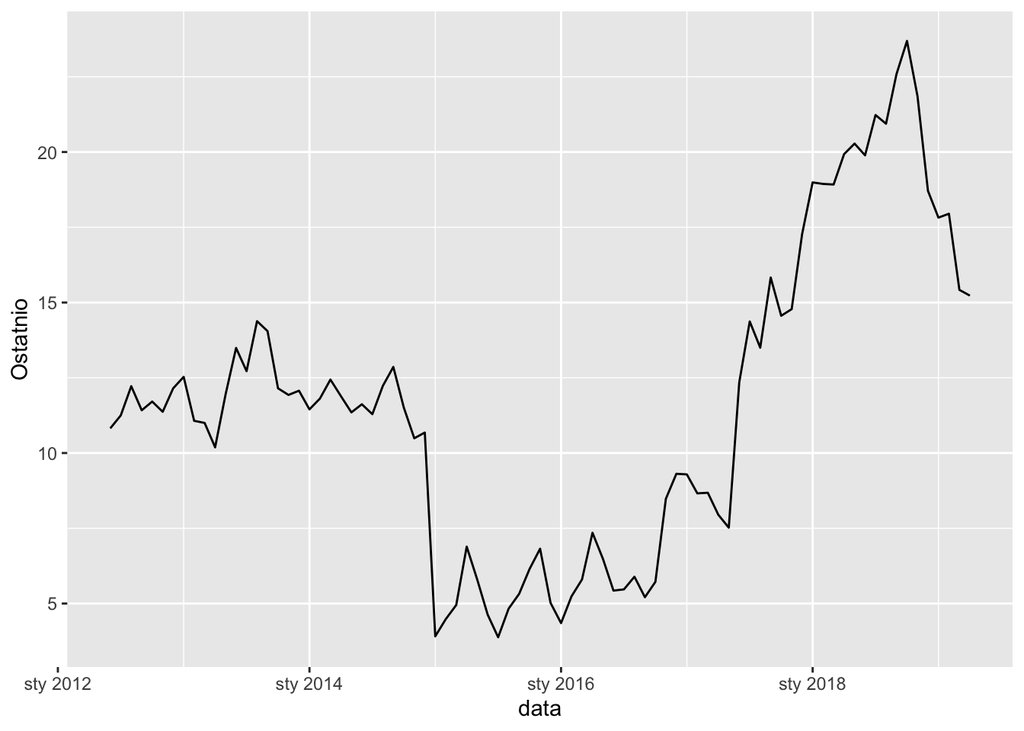

#### Dane dla Wielkiej Brytanii

UK

| Data | Ostatnio | Otwarcie | Max. | Min. | Zmiana% |
| --- | --- | --- | --- | --- | --- |
| Kwi. ’19 | 7.50 | 6.45 | 8.49 | 6.28 | 17.37 |
| Mar. ’19 | 6.39 | 8.79 | 8.87 | 6.27 | -26.97 |
| Luty ’19 | 8.75 | 7.66 | 8.96 | 6.91 | 14.98 |
| Sty. ’19 | 7.61 | 7.24 | 8.55 | 6.75 | 2.70 |
| Gru. ’18 | 7.41 | 7.84 | 7.92 | 6.54 | -4.02 |
| Lis. ’18 | 7.72 | 7.76 | 8.73 | 6.69 | 1.58 |
| Paź. ’18 | 7.60 | 8.63 | 9.80 | 6.97 | -11.63 |
| Wrz. ’18 | 8.60 | 7.84 | 9.14 | 7.52 | 10.26 |
| Sie. ’18 | 7.80 | 8.24 | 8.64 | 7.17 | -2.86 |
| Lip. ’18 | 8.03 | 7.21 | 8.41 | 6.84 | 9.70 |
| Cze. ’18 | 7.32 | 6.79 | 8.30 | 6.62 | 12.62 |
| Maj ’18 | 6.50 | 8.27 | 9.22 | 5.80 | -20.92 |
| Kwi. ’18 | 8.22 | 8.56 | 9.83 | 8.09 | -5.41 |
| Mar. ’18 | 8.69 | 8.42 | 10.23 | 7.83 | 4.07 |
| Luty ’18 | 8.35 | 7.82 | 9.01 | 7.01 | 7.46 |
| Sty. ’18 | 7.77 | 4.94 | 7.77 | 4.94 | 57.93 |
| Gru. ’17 | 4.92 | 5.62 | 6.03 | 4.55 | -13.23 |
| Lis. ’17 | 5.67 | 5.50 | 6.00 | 4.59 | 5.78 |
| Paź. ’17 | 5.36 | 5.61 | 6.24 | 4.85 | -0.74 |
| Wrz. ’17 | 5.40 | 2.04 | 5.79 | 1.68 | 163.41 |
| Sie. ’17 | 2.05 | 3.36 | 3.55 | 1.72 | -35.53 |
| Lip. ’17 | 3.18 | 4.43 | 4.60 | 2.77 | -26.39 |
| Cze. ’17 | 4.32 | 1.92 | 4.63 | 1.21 | 128.57 |
| Maj ’17 | 1.89 | 1.89 | 2.81 | 1.37 | -1.56 |
| Kwi. ’17 | 1.92 | 2.35 | 2.49 | 1.62 | -20.33 |
| Mar. ’17 | 2.41 | 2.49 | 3.24 | 1.84 | 1.69 |
| Luty ’17 | 2.37 | 2.76 | 2.91 | 0.67 | -6.69 |
| Sty. ’17 | 2.54 | 1.14 | 3.17 | 0.89 | 146.60 |
| Gru. ’16 | 1.03 | 2.19 | 2.83 | 0.80 | -53.81 |
| Lis. ’16 | 2.23 | 3.35 | 3.84 | 1.77 | -30.09 |

[output cut: 53 more lines]

#### Wykres wartości obligacji dla Wielkiej Brytanii

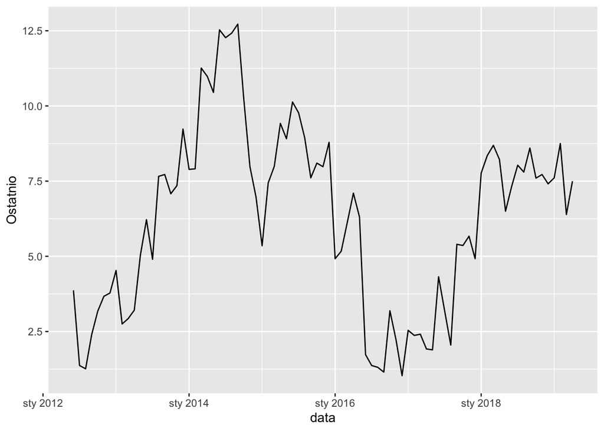

#### Dane dla Filipin

| Data | Ostatnio | Otwarcie | Max. | Min. | Zmiana% |
| --- | --- | --- | --- | --- | --- |
| Kwi. ’19 | 58.92 | 56.58 | 60.17 | 56.58 | 4.14 |
| Mar. ’19 | 56.58 | 61.26 | 61.31 | 56.58 | -7.64 |
| Luty ’19 | 61.26 | 61.06 | 61.75 | 58.81 | 0.33 |
| Sty. ’19 | 61.06 | 69.72 | 69.72 | 61.06 | -12.42 |
| Gru. ’18 | 69.72 | 67.68 | 69.72 | 67.23 | 3.01 |
| Lis. ’18 | 67.68 | 67.69 | 69.40 | 65.50 | -0.01 |
| Paź. ’18 | 67.69 | 63.81 | 76.37 | 63.81 | -3.77 |
| Wrz. ’18 | 70.34 | 53.54 | 70.34 | 53.38 | 38.66 |
| Sie. ’18 | 50.73 | 54.02 | 54.02 | 49.97 | -1.07 |
| Lip. ’18 | 51.28 | 49.72 | 51.50 | 49.32 | 2.11 |
| Cze. ’18 | 50.22 | 47.01 | 52.62 | 46.65 | 6.94 |
| Maj ’18 | 46.96 | 46.08 | 50.11 | 45.80 | 2.85 |
| Kwi. ’18 | 45.66 | 45.84 | 52.62 | 45.36 | -0.95 |
| Mar. ’18 | 46.10 | 50.37 | 53.05 | 43.00 | 8.42 |
| Luty ’18 | 42.52 | 42.02 | 48.52 | 41.96 | 1.53 |
| Sty. ’18 | 41.88 | 42.79 | 45.48 | 41.40 | -2.56 |
| Gru. ’17 | 42.98 | 42.60 | 48.32 | 42.49 | 0.70 |
| Lis. ’17 | 42.68 | 41.38 | 48.29 | 36.27 | 11.38 |
| Paź. ’17 | 38.32 | 36.43 | 41.10 | 36.43 | 4.56 |
| Wrz. ’17 | 36.65 | 36.81 | 36.81 | 36.01 | -2.21 |
| Sie. ’17 | 37.48 | 38.95 | 38.96 | 37.48 | -3.80 |
| Lip. ’17 | 38.96 | 39.25 | 40.30 | 38.82 | 0.10 |
| Cze. ’17 | 38.92 | 38.65 | 38.92 | 38.20 | 1.12 |
| Maj ’17 | 38.49 | 40.65 | 40.65 | 38.16 | -5.94 |
| Kwi. ’17 | 40.92 | 39.90 | 41.39 | 39.80 | -0.17 |
| Mar. ’17 | 40.99 | 36.92 | 41.64 | 36.92 | 11.87 |
| Luty ’17 | 36.64 | 34.24 | 36.82 | 34.21 | 7.45 |
| Sty. ’17 | 34.10 | 42.00 | 42.00 | 33.56 | -3.04 |
| Gru. ’16 | 35.17 | 36.82 | 42.21 | 35.15 | -4.14 |
| Lis. ’16 | 36.69 | 36.82 | 43.93 | 27.00 | -1.03 |

[output cut: 53 more lines]

#### Wykres wartości obligacji dla Filipin

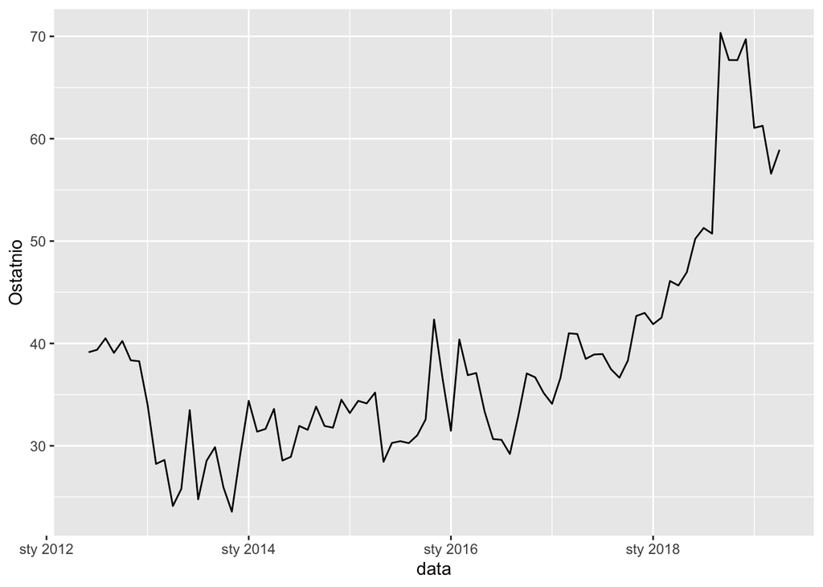

#### Dane dla Turcji

Turcja

| Data | Ostatnio | Otwarcie | Max. | Min. | Zmiana% |
| --- | --- | --- | --- | --- | --- |
| Kwi. ’19 | 21.51 | 22.29 | 22.29 | 20.06 | -1.33 |
| Mar. ’19 | 21.80 | 16.75 | 22.89 | 16.75 | 31.17 |
| Luty ’19 | 16.62 | 16.44 | 16.84 | 16.25 | 1.40 |
| Sty. ’19 | 16.39 | 17.89 | 18.67 | 16.18 | -8.38 |
| Gru. ’18 | 17.89 | 17.35 | 18.98 | 17.17 | 1.88 |
| Lis. ’18 | 17.56 | 20.77 | 20.86 | 17.04 | -15.45 |
| Paź. ’18 | 20.77 | 21.77 | 23.53 | 20.38 | -4.46 |
| Wrz. ’18 | 21.74 | 26.95 | 29.37 | 21.40 | -21.23 |
| Sie. ’18 | 27.60 | 20.28 | 29.89 | 20.20 | 36.09 |
| Lip. ’18 | 20.28 | 17.93 | 25.78 | 17.93 | 13.36 |
| Cze. ’18 | 17.89 | 16.10 | 18.58 | 16.10 | 11.12 |
| Maj ’18 | 16.10 | 13.86 | 16.62 | 13.82 | 17.35 |
| Kwi. ’18 | 13.72 | 13.71 | 14.40 | 13.47 | -0.15 |
| Mar. ’18 | 13.74 | 12.57 | 13.86 | 12.51 | 9.31 |
| Luty ’18 | 12.57 | 12.56 | 12.90 | 12.35 | 0.08 |
| Sty. ’18 | 12.56 | 12.96 | 13.99 | 12.55 | -3.38 |
| Gru. ’17 | 13.00 | 13.83 | 13.84 | 12.60 | -1.74 |
| Lis. ’17 | 13.23 | 12.39 | 14.08 | 12.34 | 6.78 |
| Paź. ’17 | 12.39 | 11.40 | 12.60 | 11.27 | 9.74 |
| Wrz. ’17 | 11.29 | 10.93 | 11.39 | 10.93 | 3.11 |
| Sie. ’17 | 10.95 | 10.95 | 11.12 | 10.83 | 0.46 |
| Lip. ’17 | 10.90 | 10.66 | 10.95 | 10.47 | 2.54 |
| Cze. ’17 | 10.63 | 10.53 | 10.72 | 10.33 | 0.95 |
| Maj ’17 | 10.53 | 10.81 | 11.03 | 10.49 | -2.68 |
| Kwi. ’17 | 10.82 | 10.84 | 11.04 | 10.59 | -0.09 |
| Mar. ’17 | 10.83 | 10.82 | 11.28 | 10.70 | 1.21 |
| Luty ’17 | 10.70 | 10.82 | 11.00 | 10.53 | -0.37 |
| Sty. ’17 | 10.74 | 10.50 | 11.60 | 10.36 | 2.58 |
| Gru. ’16 | 10.47 | 10.20 | 11.65 | 9.94 | 3.66 |
| Lis. ’16 | 10.10 | 8.97 | 10.66 | 8.88 | 13.23 |

[output cut: 53 more lines]

#### Wykres wartości obligacji dla Turcji

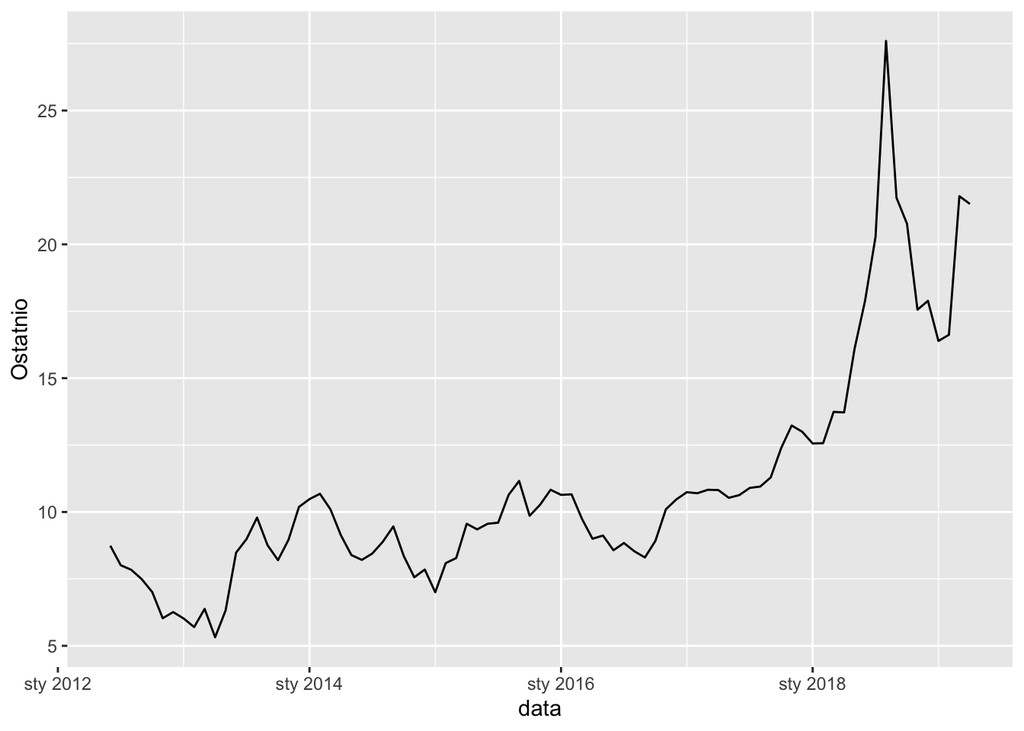

### Korelacje między zmianami miesięcznymi obligacji różnych krajów

Po utworzeniu data frame zawierającego zmiany miesięczne wartości obligacji dla 4 krajów, obliczam ich korelację.

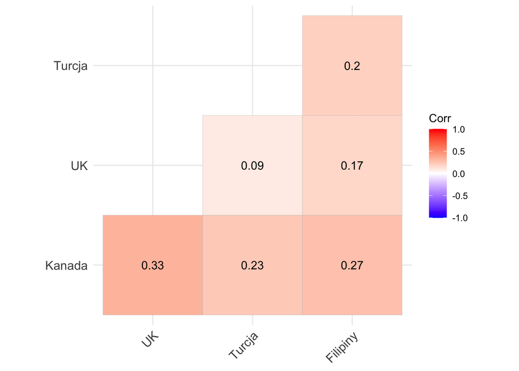

```r
zmiany<-data.frame("Kanada"=kanada$`Zmiana%`, "UK"=UK$`Zmiana%`, "Turcja"=turcja$`Zmiana%`, "Filipiny"=filipiny$`Zmiana%`)
#macierz korelacji
korelacje<-cor(zmiany)
ggcorrplot(korelacje, lab = T, type = "lower")
```

Zmiany wartości obligacji nie są ze sobą silnie skorelowane. Największa zależność jest dla Wielkiej Brytanii i Kanady 0.33, Filipin i Kanady 0.27 oraz Turcji i Kanady 0.23.

## Generowanie scenariuszy

W celu zastosowania metody Monte Carlo z wielowymiarowego rozkładu normalnego wylosowano 50 000 scenariuszy o parametrze sigma równym obliczonej macierzy korelacji.

```r
set.seed(100)
mc<-rmvnorm(50000, sigma=korelacje)
mc<-as.data.frame(mc)
mc[1:2000,] %>%
    kable(caption = 'Scenarios') %>%
    kable_styling(bootstrap_options = c('striped', 'condensed')) %>%
    scroll_box( height = "200px")
```

Scenarios

| Kanada | UK | Turcja | Filipiny |
| --- | --- | --- | --- |
| -0.5021924 | -0.0419106 | -0.1889033 | 0.7053816 |
| 0.1169713 | 0.3393847 | -0.5366127 | 0.6561885 |
| -0.8252594 | -0.6124851 | -0.1031207 | -0.1507874 |
| -0.2016340 | 0.6315621 | 0.0830252 | -0.0020982 |
| -0.3888542 | 0.3535542 | -0.9721821 | 2.0032723 |
| -0.4380900 | 0.5762385 | 0.1648287 | 0.7165609 |
| -0.8143791 | -0.6830561 | -0.8906363 | -0.1390793 |
| -1.1577295 | -0.1496101 | -0.3476678 | 1.3616967 |
| -0.1379296 | -0.1505445 | -0.7045536 | -0.3529509 |
| 0.1829077 | 0.4543283 | 1.0838555 | 1.1533397 |
| -0.1016292 | 1.2906812 | -1.7376373 | 0.4371194 |
| -0.5222834 | 1.0751784 | -0.4570112 | 1.1724465 |
| 0.0437791 | -1.7585205 | -0.4469739 | -1.8601245 |
| 0.1788648 | 1.8498870 | -2.1508876 | 0.8260764 |
| -1.3988256 | 1.2597314 | 1.0500030 | -0.8275537 |
| -0.2619958 | -0.1515980 | -0.4290646 | 2.3199302 |
| 0.1298341 | -0.6299945 | 0.6426589 | 0.2539654 |
| -0.0699169 | -0.1104052 | 0.4203902 | -0.9743594 |
| -1.1624193 | 1.1714641 | -2.2525752 | -0.4478858 |
| -1.0875283 | -0.1042551 | 0.7394943 | -2.0998891 |
| 0.8968223 | 0.2493401 | -1.1082472 | -1.7795797 |
| 0.7095816 | 0.0855909 | 0.3693715 | 0.9842904 |
| 1.7271758 | 0.4731368 | -0.1533698 | 1.7372368 |
| -0.8929574 | -1.3877126 | -0.7316027 | 1.9054274 |
| -0.8324958 | 0.1150073 | -1.3315822 | -1.4674808 |
| -0.3329234 | 1.1763715 | -0.5166985 | 0.7609056 |
| -1.4579937 | -0.8598606 | -1.0904448 | -0.8875558 |
| 1.2401015 | 0.3086338 | 0.4472468 | 0.5925420 |
| -0.6145338 | -1.5520210 | -0.4776067 | -0.2129900 |
| 1.0181200 | 0.0954301 | -0.0674279 | 1.7445471 |

[output cut: 1970 more lines]

## Przypisanie ratingów

Kolejnym krokiem było przyporządkowanie ratingów do wygenerowanych wartości w scenariuszach. W tym celu dla każdego z państw, korzystając z macierzy przejścia utworzono przedziały pozwalające przyporządkować ratingi do wartości w scenariuszu.

### Przedziały dla Kanady

```r
macierzKanada<-matrix(data=0, nrow = 4, ncol=6)
macierzKanada[1,]<-c(0.085,0.0106, 0.0028, 0.0022, 0.001, 0)
macierzKanada[2,]<-c(1, 0.085, 0.0106, 0.0028, 0.0022, 0.001)

for (i in 1:6){
  macierzKanada[3,i]=quantile(mc$Kanada,macierzKanada[1,i])
  macierzKanada[4,i]=quantile(mc$Kanada, macierzKanada[2,i])
  }
colnames(macierzKanada)<-(c("AAA", "AA", "A", "BBB", "BB", "B"))
row.names(macierzKanada)<-c("Kwantyl od", "Kwantyl do", "Wartosc od", "Wartosc do")
kable(macierzKanada)  %>%
    kable_styling(bootstrap_options = c('striped', 'condensed'))
```

|  | AAA | AA | A | BBB | BB | B |
| --- | --- | --- | --- | --- | --- | --- |
| Kwantyl od | 0.085000 | 0.010600 | 0.002800 | 0.002200 | 0.001000 | 0.000000 |
| Kwantyl do | 1.000000 | 0.085000 | 0.010600 | 0.002800 | 0.002200 | 0.001000 |
| Wartosc od | -1.352714 | -2.294359 | -2.756386 | -2.814796 | -3.026683 | -4.012439 |
| Wartosc do | 4.007258 | -1.352714 | -2.294359 | -2.756386 | -2.814796 | -3.026683 |

### Przedziały dla Wielkiej Brytanii

|  | AAA | AA | A | BBB | BB | B | CCC | D |
| --- | --- | --- | --- | --- | --- | --- | --- | --- |
| Kwantyl od | 0.993000 | 0.091500 | 0.023600 | 0.015300 | 0.004700 | 0.000300 | 0.000100 | 0.000000 |
| Kwantyl do | 1.000000 | 0.993000 | 0.091500 | 0.023600 | 0.015300 | 0.004700 | 0.000300 | 0.000100 |
| Wartosc od | 2.421189 | -1.317558 | -1.975183 | -2.151387 | -2.615892 | -3.389500 | -3.680474 | -4.328088 |
| Wartosc do | 4.246541 | 2.421189 | -1.317558 | -1.975183 | -2.151387 | -2.615892 | -3.389500 | -3.680474 |

### Przedziały dla Turcji

|  | AA | A | BBB | BB | B | CCC | D |
| --- | --- | --- | --- | --- | --- | --- | --- |
| Kwantyl od | 0.999100 | 0.997000 | 0.992100 | 0.924000 | 0.088300 | 0.000300 | 0.000000 |
| Kwantyl do | 1.000000 | 0.999100 | 0.997000 | 0.992100 | 0.924000 | 0.088300 | 0.000300 |
| Wartosc od | 3.144473 | 2.721377 | 2.404841 | 1.446706 | -1.349508 | -3.461741 | -4.260687 |
| Wartosc do | 4.102648 | 3.144473 | 2.721377 | 2.404841 | 1.446706 | -1.349508 | -3.461741 |

### Przedziały dla Filipin

|  | AAA | AA | A | BBB | BB | B | CCC | D |
| --- | --- | --- | --- | --- | --- | --- | --- | --- |
| Kwantyl od | 0.99950 | 0.99520 | 0.933800 | 0.064500 | 0.014900 | 0.003000 | 0.001800 | 0.000000 |
| Kwantyl do | 1.00000 | 0.99950 | 0.995200 | 0.933800 | 0.064500 | 0.014900 | 0.003000 | 0.001800 |
| Wartosc od | 3.20704 | 2.57412 | 1.501052 | -1.511801 | -2.153723 | -2.746707 | -2.907919 | -4.346755 |
| Wartosc do | 3.99432 | 3.20704 | 2.574120 | 1.501052 | -1.511801 | -2.153723 | -2.746707 | -2.907919 |

### Funkcja przyporzadkujaca wartość ratingu wartościom scenariusza

W celu przyporządkowania ratingów dla wartości scenariusza utworzona została funkcja porządkująca, która jako orgumenty pobiera macierz z przedziałami dla danego kraju i wartości wylosowanych scenariuszy dla danego państwa.

```r
porzadkuj<-function(macierzKraju, mcarl)
{
  if(colnames(macierzKraju)[1]=="AAA")
  {
    aaa<-which((mcarl>(macierzKraju[3,1])))
    aa<-which((mcarl<(macierzKraju[4,2]))&mcarl>(macierzKraju[3,2]))
    a<-which((mcarl<(macierzKraju[4,3]))&mcarl>(macierzKraju[3,3]))
    bbb<-which((mcarl<(macierzKraju[4,4]))&mcarl>(macierzKraju[3,4]))
    bb<-which((mcarl<(macierzKraju[4,5]))&mcarl>(macierzKraju[3,5]))
    b<-which((mcarl<(macierzKraju[4,6]))&mcarl>=(macierzKraju[3,6]))

    if(ncol(macierzKraju)>6)
      {
        ccc<-which((mcarl<(macierzKraju[4,7]))&mcarl>=(macierzKraju[3,7]))
        d<-which((mcarl<(macierzKraju[4,8]))&mcarl>=(macierzKraju[3,8]))
        mcarl[ccc]="CCC"
        mcarl[d]="D"
      }
    mcarl[aaa]="AAA"
    mcarl[aa]="AA"
    mcarl[a]="A"
    mcarl[bbb]="BBB"
    mcarl[bb]="BB"
    mcarl[b]="B"
  }
  else
  {
    aaa=0
    aa<-which((mcarl>(macierzKraju[3,1])))
    a<-which((mcarl<(macierzKraju[4,2]))&mcarl>(macierzKraju[3,2]))
    bbb<-which((mcarl<(macierzKraju[4,3]))&mcarl>(macierzKraju[3,3]))
    bb<-which((mcarl<(macierzKraju[4,4]))&mcarl>(macierzKraju[3,4]))
    b<-which((mcarl<(macierzKraju[4,5]))&mcarl>(macierzKraju[3,5]))
    ccc<-which((mcarl<(macierzKraju[4,6]))&mcarl>(macierzKraju[3,6]))
    d<-which((mcarl<(macierzKraju[4,7]))&mcarl>=(macierzKraju[3,7]))

    mcarl[aaa]="AAA"
    mcarl[aa]="AA"
    mcarl[a]="A"
    mcarl[bbb]="BBB"
    mcarl[bb]="BB"
    mcarl[b]="B"
    mcarl[ccc]="CCC"
    mcarl[d]="D"
  }
  return(mcarl)
}
```

### Przypisane ratingi do scenariuszy

W wyniku zastosowania funkcji przyporządkującej utworzony został data frame z przypisanymi wartościami ratingu dla wszystkich 50 000 scenariuszy.

Scenarios

| Kanada | UK | Turcja | Filipiny |
| --- | --- | --- | --- |
| AAA | AA | B | BBB |
| AAA | AA | B | BBB |
| AAA | AA | B | BBB |
| AAA | AA | B | BBB |
| AAA | AA | B | A |
| AAA | AA | B | BBB |
| AAA | AA | B | BBB |
| AAA | AA | B | BBB |
| AAA | AA | B | BBB |
| AAA | AA | B | BBB |
| AAA | AA | CCC | BBB |
| AAA | AA | B | BBB |
| AAA | A | B | BB |
| AAA | AA | CCC | BBB |
| AA | AA | B | BBB |
| AAA | AA | B | A |
| AAA | AA | B | BBB |
| AAA | AA | B | BBB |
| AAA | AA | CCC | BBB |
| AAA | AA | B | BB |
| AAA | AA | B | BB |
| AAA | AA | B | BBB |
| AAA | AA | B | A |
| AAA | A | B | A |
| AAA | AA | B | BBB |
| AAA | AA | B | BBB |
| AA | AA | B | BBB |
| AAA | AA | B | BBB |
| AAA | A | B | BBB |
| AAA | AA | B | A |

[output cut: 1970 more lines]

### Wyniki symulacji

Results

|  | Kanada | UK | Filipiny | Turcja |
| --- | --- | --- | --- | --- |
| AAA | 45750 | 350 | 25 | 0 |
| AA | 3720 | 45075 | 215 | 45 |
| A | 390 | 3395 | 3070 | 105 |
| BBB | 30 | 415 | 43465 | 245 |
| BB | 60 | 530 | 2480 | 3405 |
| B | 50 | 220 | 595 | 41785 |
| CCC | 0 | 10 | 60 | 4400 |
| D | 0 | 5 | 90 | 15 |

## Obliczanie wartości portfela

W obligacje 3-letnie z każdego z tych państw zainwestowano po **1 000 000 USD**.  
Do obliczenia wartości portfela dla każdego z wygenerowanych scenariuszy używam napisanej funkcji, która oblicza wartość obligacji po pierwszym roku na podstawie przeciętnych stóp zwrotu z obligacji o podanym ratingu.  
W przypadku wystąpienia ratingu D - bankructwa wartość obligacji dla danego państwa obliczamy przy pomocy ustalonej wcześniej stopy zwrotu równej 51,89%.

```r
#przecietne stopy zwrotu z obligacji
library(dplyr)
library(kableExtra)
aaa<-0.0427
aa<-0.0432
a<-0.0442
bbb<-0.0457
bb<-0.0612
b<-0.0711
ccc<-0.1452
d<-0.5189

stopy<-function(mcPanstwo, kwota){
  for (i in 1:length(mcPanstwo)){
    if(mcPanstwo[i]=="AAA"){
      mcPanstwo[i]=kwota/(1+aaa)^2
    }
    if(mcPanstwo[i]=="AA"){
      mcPanstwo[i]=kwota/(1+aa)^2
    }
    if(mcPanstwo[i]=="A"){
      mcPanstwo[i]=kwota/(1+a)^2
    }
    if(mcPanstwo[i]=="BBB"){
      mcPanstwo[i]=kwota/(1+bbb)^2
    }
    if(mcPanstwo[i]=="BB"){
      mcPanstwo[i]=kwota/(1+bb)^2
    }
    if(mcPanstwo[i]=="B"){
      mcPanstwo[i]=kwota/(1+b)^2
    }
    if(mcPanstwo[i]=="CCC"){
      mcPanstwo[i]=kwota/(1+ccc)^2
    }
    if(mcPanstwo[i]=="D"){
      mcPanstwo[i]=kwota*d
    }
  }
  return(mcPanstwo)
}

mc2<-mc
mc2$Kanada<-as.double(stopy(mc2$Kanada, 1000000))
mc2$UK<-as.double(stopy(mc2$UK, 1000000))
mc2$Turcja<-as.double(stopy(mc2$Turcja, 1000000))
mc2$Filipiny<-as.double(stopy(mc2$Filipiny, 1000000))

mc2[1:2000,] %>%
    kable(caption = 'Scenarios') %>%
    kable_styling(bootstrap_options = c('striped', 'condensed')) %>%
    scroll_box(height = "200px")
```

Scenarios

| Kanada | UK | Turcja | Filipiny |
| --- | --- | --- | --- |
| 919774.3 | 918892.8 | 871645.6 | 914504.4 |
| 919774.3 | 918892.8 | 871645.6 | 914504.4 |
| 919774.3 | 918892.8 | 871645.6 | 914504.4 |
| 919774.3 | 918892.8 | 871645.6 | 914504.4 |
| 919774.3 | 918892.8 | 871645.6 | 917133.6 |
| 919774.3 | 918892.8 | 871645.6 | 914504.4 |
| 919774.3 | 918892.8 | 871645.6 | 914504.4 |
| 919774.3 | 918892.8 | 871645.6 | 914504.4 |
| 919774.3 | 918892.8 | 871645.6 | 914504.4 |
| 919774.3 | 918892.8 | 871645.6 | 914504.4 |
| 919774.3 | 918892.8 | 762495.6 | 914504.4 |
| 919774.3 | 918892.8 | 871645.6 | 914504.4 |
| 919774.3 | 917133.6 | 871645.6 | 887984.8 |
| 919774.3 | 918892.8 | 762495.6 | 914504.4 |
| 918892.8 | 918892.8 | 871645.6 | 914504.4 |
| 919774.3 | 918892.8 | 871645.6 | 917133.6 |
| 919774.3 | 918892.8 | 871645.6 | 914504.4 |
| 919774.3 | 918892.8 | 871645.6 | 914504.4 |
| 919774.3 | 918892.8 | 762495.6 | 914504.4 |
| 919774.3 | 918892.8 | 871645.6 | 887984.8 |
| 919774.3 | 918892.8 | 871645.6 | 887984.8 |
| 919774.3 | 918892.8 | 871645.6 | 914504.4 |
| 919774.3 | 918892.8 | 871645.6 | 917133.6 |
| 919774.3 | 917133.6 | 871645.6 | 917133.6 |
| 919774.3 | 918892.8 | 871645.6 | 914504.4 |
| 919774.3 | 918892.8 | 871645.6 | 914504.4 |
| 918892.8 | 918892.8 | 871645.6 | 914504.4 |
| 919774.3 | 918892.8 | 871645.6 | 914504.4 |
| 919774.3 | 917133.6 | 871645.6 | 914504.4 |
| 919774.3 | 918892.8 | 871645.6 | 917133.6 |

[output cut: 1970 more lines]

### Obliczanie sumy portfela i strat

Następnie obliczam **wartość portfela**, czyli sumę wartości obligacji dla każdego ze scenariuszy oraz **straty**, czyli różnicę między wartością portfela, gdyby ratingi obligacji po roku nie uległy zmianie, a wartościami uzyskanymi w każdym ze scenariuszy.

Scenarios

[output not shown]

[output cut: 1970 more lines]

### Obliczanie VaR

Wyznaczone wartości strat zebrano do wektora, posortowano i obliczono **99.9% VaR**.  
Obliczony przez nas VaR wynosi **504 754.4 USD**.

```r
VaR<-NULL
VaR<-na.omit(mc2$strata)

VaR<-as.vector(VaR)
VaR<-sort(VaR)

# Kilka pierwszych wartości strat
head(VaR, 14)
```

```
##  [1]  11.29798  11.29798  11.29798  11.29798  11.29798  11.29798  11.29798
##  [8]  11.29798 881.41678 881.41678 881.41678 881.41678 881.41678 881.41678
```

```r
# Wartość VaR
quantile(VaR, 0.999)
```

```
##    99.9%
## 504754.4
```

## Podsumowanie

W wygenerowanych scenariuszach **w przeważającej większości scenariuszy** dla każdego z państw pojawiły się **ratingi identyczne z wejściowymi**. W przypadku tylko jednego państwa - **Kanady nie wystąpił scenariusz, w którym występowało bankructwo**.  
W innych państwach taki rating wystąpił, co ciekawe częściej wystąpił dla Filipin - rating wejściowy BBB niż dla Turcji - rating wejściowy B.  
Obliczona dla naszego portfela obligacji **wartość VaR wynosiła 504 754.4 USD**.  
Należy pamiętać o przyjętych w tym projekcie przybliżeniach między innymi korzystaliśmy z macierzy przejścia dla obligacji korporacyjnych, a nie rządowych, stopy procentowe również nie były aktualne. Przybliżenia te mogły mieć wpływ na otrzymane wyniki, więc nie należy wyciągać wniosków znajdujących realne odniesienie w rzeczywistości.

### Bibliografia

Wykłady **Ilościowe aspekty ryzyka** dr Jacka Wolaka  
https://pl.investing.com  
https://tradingeconomics.com  
http://www.kzm.pwsztar.edu.pl/~kzm_matematyka/szkola/referaty/Szwedo.pdf  
https://biznes.interia.pl/makroekonomia/news/nowe-tygrysy-rosna-w-sile,2604551  
https://pl.wikipedia.org/wiki/Wikipedia:Strona_główna